# Final Project: Analysis of Males with Heart Attack

Maria Alvarez

2025-02-21

## Introduction

Heart disease is the leading cause of death for men in the United States. Every year, about 805,000 people in the United States have a heart attack. Of these, 605,000 are first heart attacks, and 200,000 happen to people who have already had a heart attack1. The average age at the first heart attack is 65.6 years for males2. Approximately every 40 seconds, someone in the United States will have a myocardial infarction.

The analyzed dataset comes from the Panel Study of Income Dynamics (PSID) conducted by the Michigan Institute for Social Research. The PSID is the longest-running longitudinal household survey in the world. It began in 1968 with a nationally representative sample of over 18,000 individuals living in 5,000 families in the United States. Information has been continuously collected on these individuals and their descendants, covering a wide range of topics including employment, income, wealth, expenditures, health, marriage, childbearing, child development, philanthropy, and education.

For this project, I will be analyzing a sample of males who have been tracked since 1999 and still remain in the survey until 2021. This sample specifically includes males who identified as the reference or head of their household and have experienced a heart attack. Key variables in the analysis will include: history of heart disease, age at heart attack, family income level, education level, diagnosis of diabetes, hypertension, stroke events, and psychiatric conditions, such as depression.

## Descriptive Statistics

[output not shown]

<sup>1</sup> n (%); Median (Q1, Q3)  
<sup>2</sup> Fisher’s exact test; Kruskal-Wallis rank sum test

The table above provides descriptive statistics for selected variables in the dataset, including comparisons between different age groups. The total sample includes 230 males identified as the head of their households who reported experiencing a heart attack. Key findings include:

72% were married, while the remaining 28% were widowed, divorced, separated, or never married.

31% of the individuals reported an annual income between $50,000 and $100,000, with males older than 65 years being the primary recipients of this income bracket.

## Figure 1. Distribution of Age at First Heart Attack

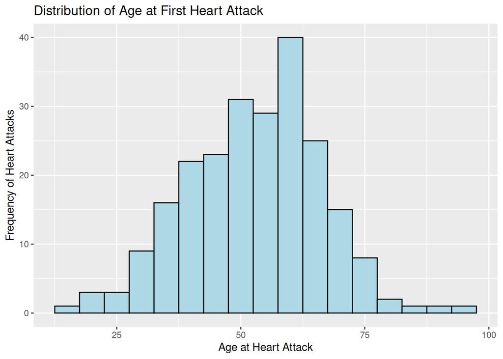

## Conclusion

This analysis highlights important patterns and associations in the dataset of males with a history of heart attacks. The findings can be used to inform health interventions targeting specific demographics. Future research should investigate additional factors, such as physical activity or genetic predisposition, that may influence the occurrence of heart attacks.

## References

American Heart Association Statistics, 2025.

Panel Study of Income Dynamics (PSID), University of Michigan.